# Lab 4: MATH 4753

Justin Kleiber

2019-09-20

# Task 1

First, the working directory is confirmed

```r
getwd()
```

```
## [1] "C:/Users/jklei/Google Drive/School/Fall 2019/MATH4573/Lab5"
```

# Task 2

A binomial distribution can be simulated using the `mybin()` function declared below.

```r
## sampling function
# iter = iterations, n=sample size
# set default values
mybin=function(iter=100,n=10, p=0.5){
  # make a matrix to hold the samples
  #initially filled with NA's
  sam.mat=matrix(NA,nr=n,nc=iter, byrow=TRUE)

  #Make a vector to hold the number of successes in each trial
  succ=c()

  for( i in 1:iter){
    #Fill each column with a new sample
    sam.mat[,i]=sample(c(1,0),n,replace=TRUE, prob=c(p,1-p))
    #Calculate a statistic from the sample (this case it is the sum)
    succ[i]=sum(sam.mat[,i])
  }

  #Make a table of successes
  succ.tab=table(factor(succ,levels=0:n))

  #Make a barplot of the proportions
  barplot(succ.tab/(iter), col=rainbow(n+1), main="Binomial simulation", xlab="Number of successes")
  succ.tab/iter
}
```

For n=10 and p=0.7, at  
* 100 iterations:

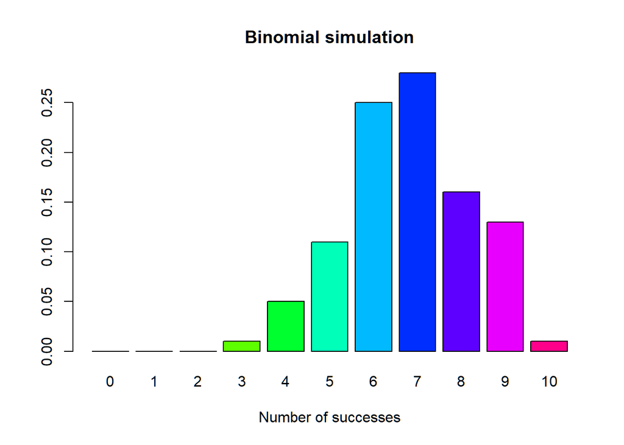

```
##
##    0    1    2    3    4    5    6    7    8    9   10
## 0.00 0.00 0.00 0.01 0.05 0.11 0.25 0.28 0.16 0.13 0.01
```

```r
mybin(iter=100, n=10, p=0.7)
```

- 200 iterations:

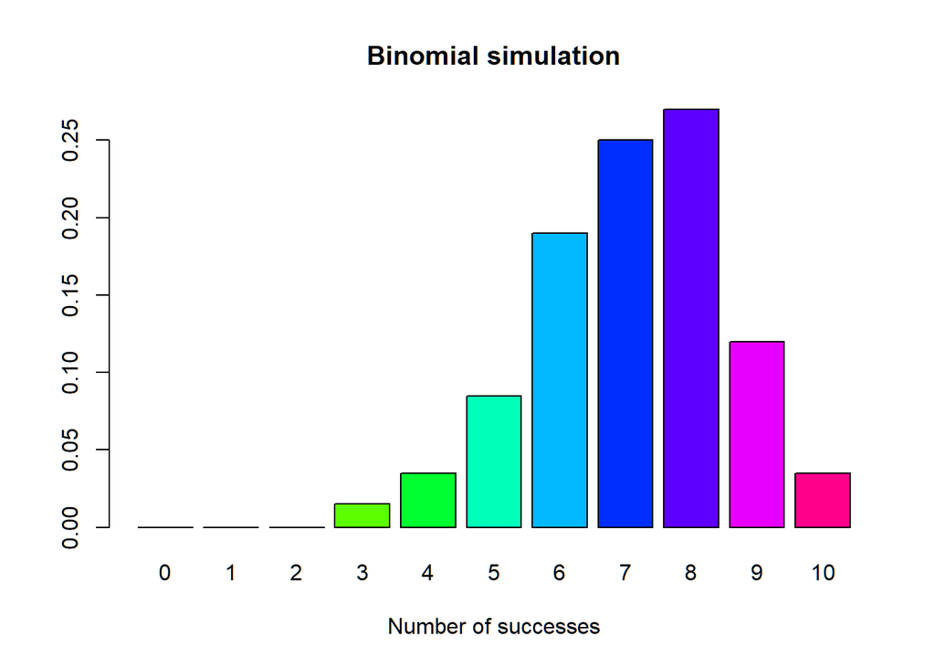

```
##
##     0     1     2     3     4     5     6     7     8     9    10
## 0.000 0.000 0.000 0.015 0.035 0.085 0.190 0.250 0.270 0.120 0.035
```

```r
mybin(iter=200, n=10, p=0.7)
```

- 500 iterations:

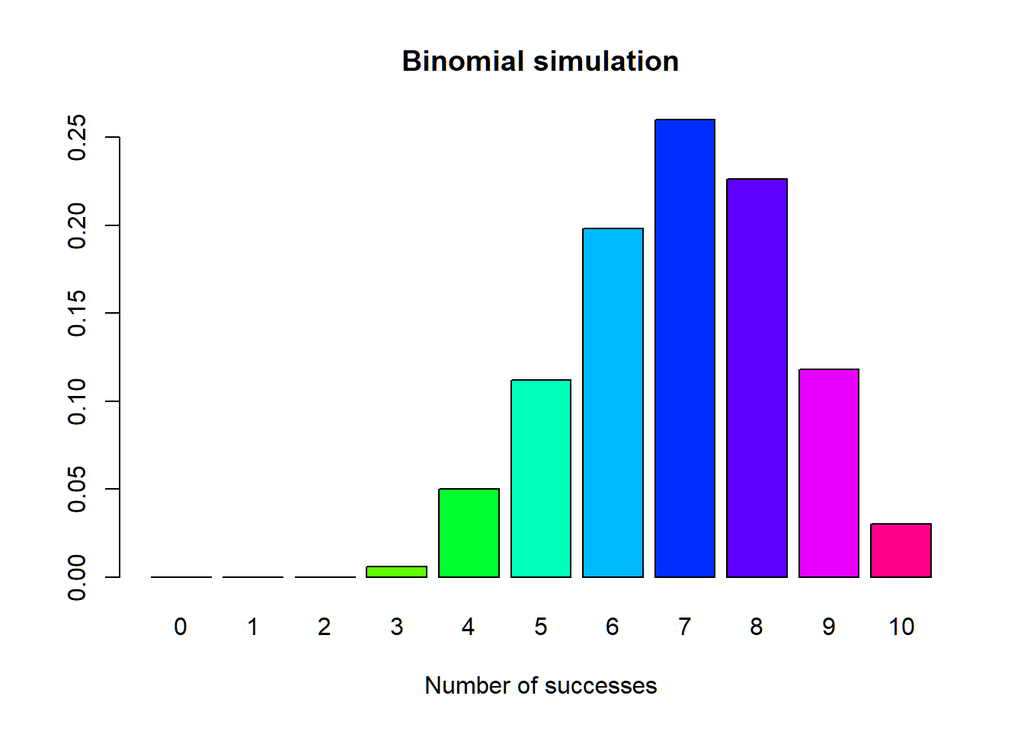

```
##
##     0     1     2     3     4     5     6     7     8     9    10
## 0.000 0.000 0.000 0.006 0.050 0.112 0.198 0.260 0.226 0.118 0.030
```

```r
mybin(iter=500, n=10, p=0.7)
```

- 1000 iterations:

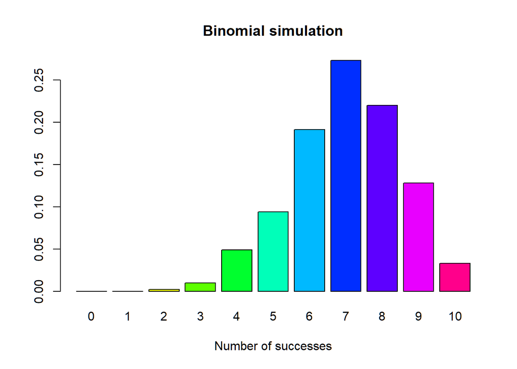

```
##
##     0     1     2     3     4     5     6     7     8     9    10
## 0.000 0.000 0.002 0.010 0.049 0.094 0.191 0.273 0.220 0.128 0.033
```

```r
mybin(iter=1000, n=10, p=0.7)
```

- 10000 iterations:

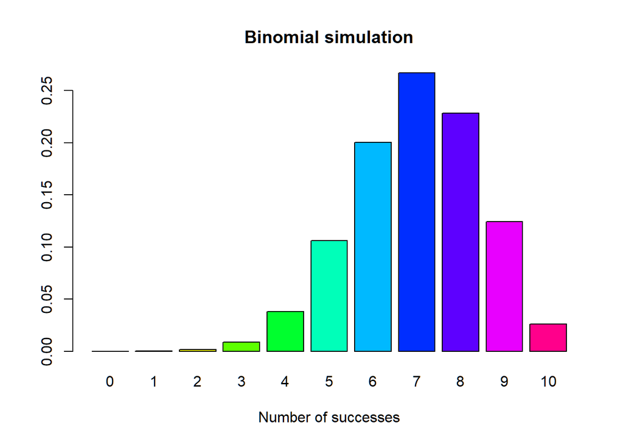

```
##
##      0      1      2      3      4      5      6      7      8      9
## 0.0000 0.0001 0.0017 0.0086 0.0380 0.1059 0.2001 0.2669 0.2281 0.1244
##     10
## 0.0262
```

```r
mybin(iter=10000, n=10, p=0.7)
```

Using `dbinom` these values can be verified:

```r
validator = function(size=10) {
  vals = c()
  for (i in 1:size)
  {
    vals[i] = dbinom(i,10,0.7)
  }

  vals.df = data.frame(vals)
  vals.df
}

validator()
```

```
##           vals
## 1  0.000137781
## 2  0.001446701
## 3  0.009001692
## 4  0.036756909
## 5  0.102919345
## 6  0.200120949
## 7  0.266827932
## 8  0.233474440
## 9  0.121060821
## 10 0.028247525
```

And as seen, the values produced by `dbinom` are close to those in the 10,000 iteration simulation.

# Task 3

Creating a sample of 5 marbles without replacement:

```r
marbles = sample(1:20, 5, replace = FALSE)
```

Number of white marbles:

```r
length(marbles[marbles <= 12])
```

```
## [1] 3
```

Number of black marbles

```r
length(marbles[marbles > 12])
```

```
## [1] 2
```

Creating a sample of 5 marbles with replacement:

```r
marbles = sample(1:20, 5, replace = TRUE)
```

Number of white marbles:

```r
length(marbles[marbles <= 12])
```

```
## [1] 3
```

Number of black marbles

```r
length(marbles[marbles > 12])
```

```
## [1] 2
```

The following function is used to simulate a hypergeometric distribution:

```r
myhyper=function(iter=100,N=20,r=12,n=5){
  # make a matrix to hold the samples
  #initially filled with NA's
  sam.mat=matrix(NA,nr=n,nc=iter, byrow=TRUE)

  #Make a vector to hold the number of successes over the trials
  succ=c()
  for( i in 1:iter){
    #Fill each column with a new sample
    sam.mat[,i]=sample(rep(c(1,0),c(r,N-r)),n,replace=FALSE)
    #Calculate a statistic from the sample (this case it is the sum)
    succ[i]=sum(sam.mat[,i])
  }

  #Make a table of successes
  succ.tab=table(factor(succ,levels=0:n))

  #Make a barplot of the proportions
  barplot(succ.tab/(iter), col=rainbow(n+1), main="HYPERGEOMETRIC simulation", xlab="Number of successes")

  succ.tab/iter
}
```

- 100 iterations:

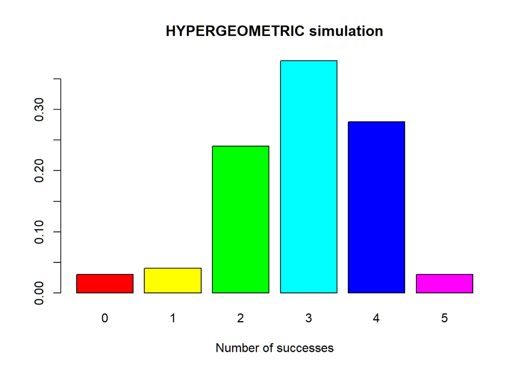

```
##
##    0    1    2    3    4    5
## 0.03 0.04 0.24 0.38 0.28 0.03
```

```r
myhyper(iter=100)
```

- 200 iterations:

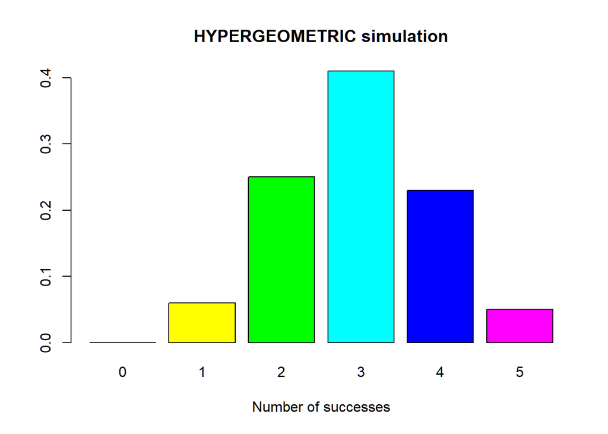

```
##
##    0    1    2    3    4    5
## 0.00 0.06 0.25 0.41 0.23 0.05
```

```r
myhyper(iter=200)
```

- 500 iterations:

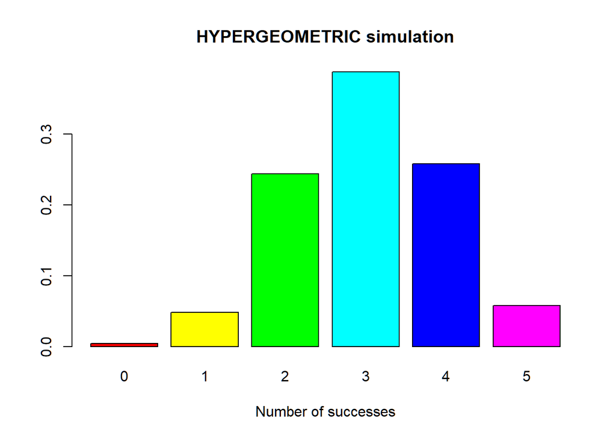

```
##
##     0     1     2     3     4     5
## 0.004 0.048 0.244 0.388 0.258 0.058
```

```r
myhyper(iter=500)
```

- 1000 iterations:

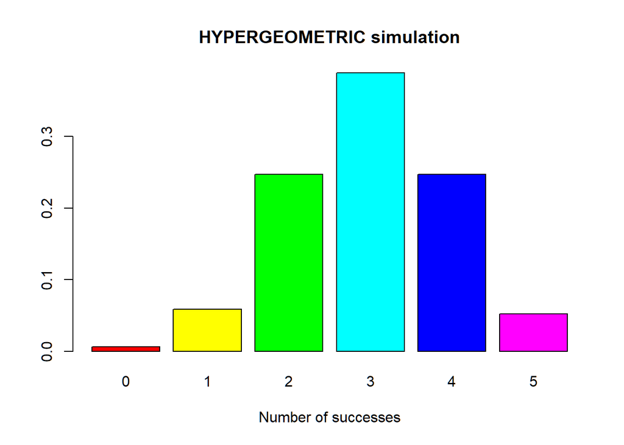

```
##
##     0     1     2     3     4     5
## 0.006 0.059 0.247 0.389 0.247 0.052
```

```r
myhyper(iter=1000)
```

- 10000 iterations:

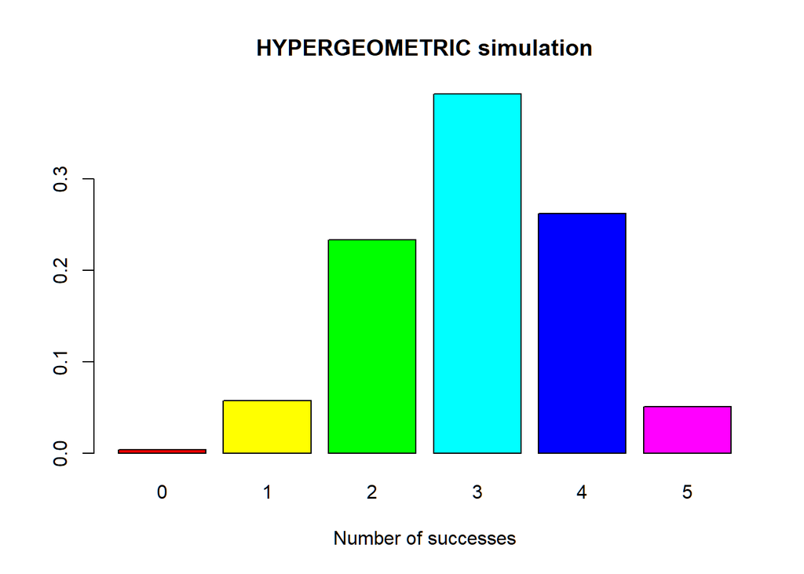

```
##
##      0      1      2      3      4      5
## 0.0040 0.0575 0.2333 0.3928 0.2618 0.0506
```

```r
myhyper(iter=10000)
```

Using `dhyper` these values can be validated:

```r
validator = function(size=5) {
  vals = c()
  for (i in 1:size)
  {
    vals[i] = dhyper(i,12,8,size)
  }

  vals.df = data.frame(vals)
  vals.df
}

validator()
```

```
##         vals
## 1 0.05417957
## 2 0.23839009
## 3 0.39731682
## 4 0.25541796
## 5 0.05108359
```

From this analysis, it can be seen that the iterative values are close to the `dhyper` values

# Task 4

The `mysample` function looks like it will make a sample and then plot the relative frequency of each possible value in the sample. Every loop it has a delay to show the plot and then it will move to the next one.

```r
mysample=function(n, iter=10,time=0.5){
  for( i in 1:iter){
    #make a sample
    s=sample(1:10,n,replace=TRUE)
    # turn the sample into a factor
    sf=factor(s,levels=1:10)
    #make a barplot
    barplot(table(sf)/n,beside=TRUE,col=rainbow(10),
    main=paste("Example sample()", " iteration ", i, " n= ", n,sep="") ,
    ylim=c(0,0.2)
    )

    #release the table
    Sys.sleep(time)
  }
}

mysample(n = 1000, iter = 30, time = 1)
```

If the above function was run in a script, the relative frequency graph of the random samples is shown as a sort of animation.

Here is an example of one frame of the ‘animation’

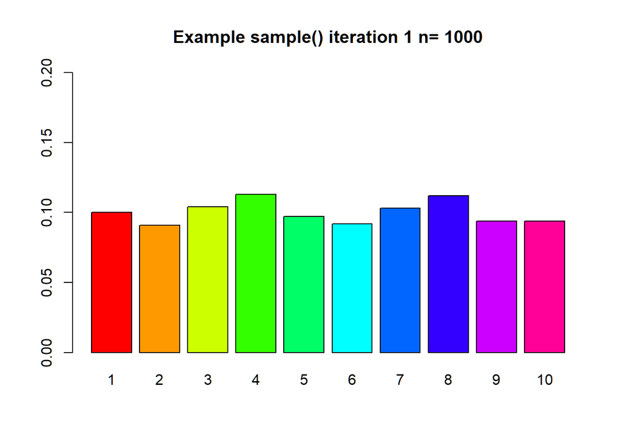

```r
mysample=function(n, iter=10,time=0.5){
  for( i in 1:iter){
    #make a sample
    s=sample(1:10,n,replace=TRUE)
    # turn the sample into a factor
    sf=factor(s,levels=1:10)
    #make a barplot
    barplot(table(sf)/n,beside=TRUE,col=rainbow(10),
    main=paste("Example sample()", " iteration ", i, " n= ", n,sep="") ,
    ylim=c(0,0.2)
    )

    #release the table
    Sys.sleep(time)
  }
}

mysample(n = 1000, iter = 1, time = 1)
```

# Task 5

Calculating 8 choose 4 is done in R as follows:

```r
choose(8,4)
```

```
## [1] 70
```

We can use `ppois` to calculate the likelihood of a value being above 4 in a Poisson distribution (for $\lambda = 2$):

```r
1 - ppois(4, 2)
```

```
## [1] 0.05265302
```

Calculating the probability of y=10 in a negative binomial with p=0.4 and r = 3:

```r
dnbinom(10-3, size=3, prob=0.4)
```

```
## [1] 0.06449725
```

Calculating the probability of y <= 8 in a binomial distribution:

```r
pbinom(8, 15, 0.4)
```

```
## [1] 0.9049526
```

# Task 6

```r
library(JKleiberPkg)
JKleiberPkg::obinom(6, 0.8)
```

```
##       prob
## 1 0.001536
## 2 0.015360
## 3 0.081920
## 4 0.245760
## 5 0.393216
## 6 0.262144
```